# Lesson 12: Data management & transformation in R

Modesto

2022-12-14 (17:11 h)

# Wellcome & Disclaimer

This site contains the materials for the *Coding tools for Biochemistry & Molecular Biology* (Herramientas de Programación para Bioquímica y Biología Molecular) course of fall 2022 in the Bachelor’s Degree in Biochemistry @UAM. This materials are the basis for GitHub-pages-based website that can be accessed [here](https://mredrejo.github.io/HPBBM2022/). Detailed academic information about the course contents, dates and assessment only can be found at the UAM Moodle site.

All this material is open access and it is shared under [CC BY-NC](https://creativecommons.org/licenses/by-nc/2.0/) license.

# Transform dataframes

## Sorting and subsetting data

When you want to present or analyze your data in R you often need to order a vector or a dataframe by the value of a variable. This order might be increasing or decreasing, numeric or alphabetic. There are two main functions in R to arrange your data, `sort()` and `order()`.

Let’s see an example using the dataset *coli_genomes_renamed.csv* that we saved in the Lesson 9*.*

```r
# load the dataset
coli_genomes <- read.csv2(file = "data/coli_genomes_renamed.csv")

# test sort() & order() in a vector
order(coli_genomes$Year)
```

```
##  [1] 15  7  8  6  3  2  5 14 16 17 18 20 22  9 10 11 12 13 19 21  1  4
```

```r
sort(coli_genomes$Year)
```

```
##  [1] 2005 2006 2006 2007 2008 2010 2011 2011 2012 2012 2012 2012 2012 2013 2013
## [16] 2013 2013 2013 2015 2016
```

```r
sort(coli_genomes$Year, decreasing = TRUE)
```

```
##  [1] 2016 2015 2013 2013 2013 2013 2013 2012 2012 2012 2012 2012 2011 2011 2010
## [16] 2008 2007 2006 2006 2005
```

```r
order(coli_genomes$Phylogroup)
```

```
##  [1]  4  5  6  7  8 12 13 18 20 21  3 14 22  2 15 16 17 19  1  9 10 11
```

```r
sort(coli_genomes$Phylogroup)
```

```
##  [1] "A"  "A"  "A"  "A"  "A"  "A"  "A"  "A"  "A"  "A"  "B1" "B1" "B1" "C"  "C"
## [16] "C"  "C"  "C"  "D"  "D"  "D"  "D"
```

As you noticed, the R `order()` function returns a permutation of the order of the elements of a vector. The output is an index vector, not the vector itself. Note also that if the vector contains any `NA` values there will be at the end of the index vector by default.

On the other hand, the `sort()` function returns sorted, in ascending order by default, the vector you pass as input.

Both function will arrange the data increasingly, and can be used for numeric or string variables. If you set the `decreasing` argument to `TRUE` in a `sort()` or `order()`, you will have the vector of indices in descending order.

You can use these functions also to arrange a dataframe by one vector. Alternatively, you may want to reverse order or *shuffle* a dataframe.

```r
# order the dataframe by one column, sort or order?
coli_genomes[order(coli_genomes$Year), ]
```

|  | Strain | Biosample | Year | Source | Phylogroup | Serotype | Clonotype | Sequence.Type | VF | Plasmids | kmer | Contigs | N50 | longest.contig..bp. | Assembly_length | contigs1kb | average_contig |
| --- | --- | --- | --- | --- | --- | --- | --- | --- | --- | --- | --- | --- | --- | --- | --- | --- | --- |
| 15 | LREC255 | SAMN14278630 | 2005 | Avian | C | O78:H19 | CH4-27 | ST88 | 11 | 4 | 113 | 108 | 405376 | 1190696 | 5196698 | 38 | 48117.57 |
| 7 | LREC244 | SAMN14278619 | 2006 | Porcine | A | O2:H32 | CH11-23 | ST10 | 4 | 7 | 115 | 277 | 89185 | 281444 | 5406295 | 155 | 19517.31 |
| 8 | LREC245 | SAMN14278620 | 2006 | Porcine | A | ONT:H45 | C11-398 | ST10888 | 2 | 7 | 115 | 203 | 94368 | 280268 | 4796593 | 114 | 23628.54 |
| 6 | LREC243 | SAMN14278618 | 2007 | Porcine | A | O9:H37 | CH7-31 | ST3011 | 7 | 3 | 93 | 158 | 106897 | 369508 | 4638334 | 93 | 29356.54 |
| 3 | LREC240 | SAMN14278615 | 2008 | Human | B1 | O76:H30 | CH29-38 | ST156 | 10 | 2 | 89 | 114 | 270767 | 738861 | 4875343 | 47 | 42766.17 |
| 2 | LREC239 | SAMN14278614 | 2010 | Human | C | O153:H19 | CH4-25 | ST88 | 14 | 3 | 117 | 159 | 323172 | 760527 | 5415613 | 57 | 34060.46 |
| 5 | LREC242 | SAMN14278617 | 2011 | Porcine | A | ONT:HNM | CH7-54 | ST746 | 5 | 9 | 89 | 320 | 45936 | 128053 | 4858138 | 212 | 15181.68 |
| 14 | LREC254 | SAMN14278629 | 2011 | Avian | B1 | O142:H30 | C41-35 | ST359 | 9 | 4 | 113 | 102 | 240847 | 460510 | 4992565 | 42 | 48946.72 |
| 16 | LREC256 | SAMN14278631 | 2012 | Human | C | O8:H19 | CH4-54 | ST88 | 14 | 2 | 113 | 108 | 281822 | 1140163 | 5252065 | 43 | 48630.23 |
| 17 | LREC257 | SAMN14278632 | 2012 | Human | C | O9:H19 | CH4-27 | ST88 | 14 | 4 | 91 | 224 | 140521 | 284241 | 5085107 | 110 | 22701.37 |

[output cut: 12 more lines]

```r
coli_genomes[sort(coli_genomes$Year), ]  #what happened?
```

|  | Strain | Biosample | Year | Source | Phylogroup | Serotype | Clonotype | Sequence.Type | VF | Plasmids | kmer | Contigs | N50 | longest.contig..bp. | Assembly_length | contigs1kb | average_contig |
| --- | --- | --- | --- | --- | --- | --- | --- | --- | --- | --- | --- | --- | --- | --- | --- | --- | --- |
| NA | NA | NA | NA | NA | NA | NA | NA | NA | NA | NA | NA | NA | NA | NA | NA | NA | NA |
| NA.1 | NA | NA | NA | NA | NA | NA | NA | NA | NA | NA | NA | NA | NA | NA | NA | NA | NA |
| NA.2 | NA | NA | NA | NA | NA | NA | NA | NA | NA | NA | NA | NA | NA | NA | NA | NA | NA |
| NA.3 | NA | NA | NA | NA | NA | NA | NA | NA | NA | NA | NA | NA | NA | NA | NA | NA | NA |
| NA.4 | NA | NA | NA | NA | NA | NA | NA | NA | NA | NA | NA | NA | NA | NA | NA | NA | NA |
| NA.5 | NA | NA | NA | NA | NA | NA | NA | NA | NA | NA | NA | NA | NA | NA | NA | NA | NA |
| NA.6 | NA | NA | NA | NA | NA | NA | NA | NA | NA | NA | NA | NA | NA | NA | NA | NA | NA |
| NA.7 | NA | NA | NA | NA | NA | NA | NA | NA | NA | NA | NA | NA | NA | NA | NA | NA | NA |
| NA.8 | NA | NA | NA | NA | NA | NA | NA | NA | NA | NA | NA | NA | NA | NA | NA | NA | NA |
| NA.9 | NA | NA | NA | NA | NA | NA | NA | NA | NA | NA | NA | NA | NA | NA | NA | NA | NA |

[output cut: 10 more lines]

```r
# Custom order of rows (random)
coli_genomes[sample(nrow(coli_genomes), replace = FALSE), ]
```

|  | Strain | Biosample | Year | Source | Phylogroup | Serotype | Clonotype | Sequence.Type | VF | Plasmids | kmer | Contigs | N50 | longest.contig..bp. | Assembly_length | contigs1kb | average_contig |
| --- | --- | --- | --- | --- | --- | --- | --- | --- | --- | --- | --- | --- | --- | --- | --- | --- | --- |
| 21 | LREC261 | SAMN14278636 | 2016 | Human | A | O98:H26 | CH27-23 | ST8233 | 2 | 4 | 89 | 114 | 187945 | 537848 | 4821342 | 53 | 42292.47 |
| 14 | LREC254 | SAMN14278629 | 2011 | Avian | B1 | O142:H30 | C41-35 | ST359 | 9 | 4 | 113 | 102 | 240847 | 460510 | 4992565 | 42 | 48946.72 |
| 4 | LREC241 | SAMN14278616 | NA | Human | A | O78:H11 | CH11-41 | ST48 | 5 | 3 | 117 | 212 | 112160 | 285056 | 5167401 | 101 | 24374.53 |
| 3 | LREC240 | SAMN14278615 | 2008 | Human | B1 | O76:H30 | CH29-38 | ST156 | 10 | 2 | 89 | 114 | 270767 | 738861 | 4875343 | 47 | 42766.17 |
| 6 | LREC243 | SAMN14278618 | 2007 | Porcine | A | O9:H37 | CH7-31 | ST3011 | 7 | 3 | 93 | 158 | 106897 | 369508 | 4638334 | 93 | 29356.54 |
| 13 | LREC253 | SAMN14278628 | 2013 | Avian | A | ONT:H19 | CH94-23 | ST347 | 2 | 0 | 117 | 134 | 110661 | 497785 | 4664768 | 77 | 34811.70 |
| 7 | LREC244 | SAMN14278619 | 2006 | Porcine | A | O2:H32 | CH11-23 | ST10 | 4 | 7 | 115 | 277 | 89185 | 281444 | 5406295 | 155 | 19517.31 |
| 19 | LREC259 | SAMN14278634 | 2015 | Human | C | O9:H19 | CH4like-27 | ST10890 | 13 | 3 | 113 | 171 | 326962 | 749412 | 5200701 | 77 | 30413.46 |
| 8 | LREC245 | SAMN14278620 | 2006 | Porcine | A | ONT:H45 | C11-398 | ST10888 | 2 | 7 | 115 | 203 | 94368 | 280268 | 4796593 | 114 | 23628.54 |
| 16 | LREC256 | SAMN14278631 | 2012 | Human | C | O8:H19 | CH4-54 | ST88 | 14 | 2 | 113 | 108 | 281822 | 1140163 | 5252065 | 43 | 48630.23 |

[output cut: 12 more lines]

```r
# Reverse order of rows
coli_genomes[nrow(coli_genomes):1, ]
```

|  | Strain | Biosample | Year | Source | Phylogroup | Serotype | Clonotype | Sequence.Type | VF | Plasmids | kmer | Contigs | N50 | longest.contig..bp. | Assembly_length | contigs1kb | average_contig |
| --- | --- | --- | --- | --- | --- | --- | --- | --- | --- | --- | --- | --- | --- | --- | --- | --- | --- |
| 22 | LREC262 | SAMN14278637 | 2012 | Human | B1 | O66:H10 | CH4-32 | ST1049 | 4 | 2 | 113 | 94 | 325747 | 822206 | 4839344 | 32 | 51482.38 |
| 21 | LREC261 | SAMN14278636 | 2016 | Human | A | O98:H26 | CH27-23 | ST8233 | 2 | 4 | 89 | 114 | 187945 | 537848 | 4821342 | 53 | 42292.47 |
| 20 | LREC260 | SAMN14278635 | 2012 | Human | A | ONT:H33 | CH11-54 | ST10 | 2 | 5 | 117 | 120 | 228491 | 576949 | 4881205 | 48 | 40676.71 |
| 19 | LREC259 | SAMN14278634 | 2015 | Human | C | O9:H19 | CH4like-27 | ST10890 | 13 | 3 | 113 | 171 | 326962 | 749412 | 5200701 | 77 | 30413.46 |
| 18 | LREC258 | SAMN14278633 | 2012 | Human | A | O9:H4 | CH7-34 | ST46 | 8 | 4 | 85 | 204 | 86565 | 300086 | 4915667 | 121 | 24096.41 |
| 17 | LREC257 | SAMN14278632 | 2012 | Human | C | O9:H19 | CH4-27 | ST88 | 14 | 4 | 91 | 224 | 140521 | 284241 | 5085107 | 110 | 22701.37 |
| 16 | LREC256 | SAMN14278631 | 2012 | Human | C | O8:H19 | CH4-54 | ST88 | 14 | 2 | 113 | 108 | 281822 | 1140163 | 5252065 | 43 | 48630.23 |
| 15 | LREC255 | SAMN14278630 | 2005 | Avian | C | O78:H19 | CH4-27 | ST88 | 11 | 4 | 113 | 108 | 405376 | 1190696 | 5196698 | 38 | 48117.57 |
| 14 | LREC254 | SAMN14278629 | 2011 | Avian | B1 | O142:H30 | C41-35 | ST359 | 9 | 4 | 113 | 102 | 240847 | 460510 | 4992565 | 42 | 48946.72 |
| 13 | LREC253 | SAMN14278628 | 2013 | Avian | A | ONT:H19 | CH94-23 | ST347 | 2 | 0 | 117 | 134 | 110661 | 497785 | 4664768 | 77 | 34811.70 |

[output cut: 12 more lines]

Now, imagine you have a large dataset and you want to subset only some cases (=rows). You know already some ways to do that, but in the following example we are going to test the function `subset()` that is very convenient when you want to extract the cases that that fulfill several conditions.

Imagine that for a new project we want to select the strains with better genome draft quality or from some subgroup. We will keep strains from phylogrupo A, with an assembly N50>150,000 bp and less than 100 contigs >= 1 kb.

```r
# option 1: multi-step
selection <- coli_genomes[coli_genomes$contigs1kb < 100, ]
selection <- selection[selection$N50 > 150000, ]
selection <- selection[selection$Phylogroup == "A", ]

# option 2: several which statements
selection2 <- coli_genomes[which(coli_genomes$contigs1kb < 100 &
    coli_genomes$N50 > 150000 & coli_genomes$Phylogroup == "A"),
    ]

# option 2b:with attach(dataframe) you avoid repeat the
# name of the dataframe
attach(coli_genomes)
selection2 <- coli_genomes[which(contigs1kb < 100 & N50 > 150000 &
    Phylogroup == "A"), ]
detach(coli_genomes)  #detach dataframe

# option 3: subset() does the same
selection3 <- subset(coli_genomes, subset = contigs1kb < 100 &
    N50 > 150000 & Phylogroup == "A")

# Are they the same?
all.equal(selection, selection2)
```

```
## [1] TRUE
```

```r
all.equal(selection, selection3)
```

```
## [1] TRUE
```

It you want to verify that the three methods will give rise to the same output you can review the dataframe, or check their dimensions or structure with `dim()` or `str()`, but that is difficult for large datasets with hundreds or thousands of cases (see below). The function `all.equal()` will do that for you.

## Combining dataframes

When you work with a lot of data, you may have several tables and sometimes you want to merge the tables in different ways. An easy way can be the use of `cbind()` or `rbind()` if you have the same number of rows and columns. A more handy way is using the function `merge()`. We will see some alternatives using the *coli_genomes* dataframe and a new table, named *colis3.csv.*

```r
colis <- read.csv2(file = "data/colis3.csv")
# rbind() and cbind()
rbind(coli_genomes, colis)  #did it work? why??
```

```
## Error in rbind(deparse.level, ...): numbers of columns of arguments do not match
```

```r
cbind(coli_genomes, colis)
```

```
## Error in data.frame(..., check.names = FALSE): arguments imply differing number of rows: 22, 27
```

```r
# merge()
merge <- merge(coli_genomes, colis)  #inner join
str(merge)
```

```
## 'data.frame':    22 obs. of  24 variables:
##  $ Strain             : chr  "LREC237" "LREC239" "LREC240" "LREC241" ...
##  $ Year               : int  NA 2010 2008 NA 2011 2007 2006 2006 2013 2013 ...
##  $ Biosample          : chr  "SAMN14278613" "SAMN14278614" "SAMN14278615" "SAMN14278616" ...
##  $ Source             : chr  "Human" "Human" "Human" "Human" ...
##  $ Phylogroup         : chr  "D" "C" "B1" "A" ...
##  $ Serotype           : chr  "ONT:H28" "O153:H19" "O76:H30" "O78:H11" ...
##  $ Clonotype          : chr  "CH23-331" "CH4-25" "CH29-38" "CH11-41" ...
##  $ Sequence.Type      : chr  "ST524" "ST88" "ST156" "ST48" ...
##  $ VF                 : int  18 14 10 5 5 7 4 2 22 22 ...
##  $ Plasmids           : int  3 3 2 3 9 3 7 7 1 3 ...
##  $ kmer               : int  117 117 89 117 89 93 115 115 115 111 ...
##  $ Contigs            : int  223 159 114 212 320 158 277 203 376 205 ...
##  $ N50                : int  272287 323172 270767 112160 45936 106897 89185 94368 200150 281589 ...
##  $ longest.contig..bp.: int  662555 760527 738861 285056 128053 369508 281444 280268 424527 617142 ...
##  $ Assembly_length    : int  5341632 5415613 4875343 5167401 4858138 4638334 5406295 4796593 5389075 5340478 ...
##  $ contigs1kb         : int  74 57 47 101 212 93 155 114 131 78 ...
##  $ average_contig     : num  23954 34060 42766 24375 15182 ...
##  $ X                  : int  1 2 3 4 5 6 7 8 12 13 ...
##  $ CRISPR             : int  9 12 5 9 9 10 7 10 7 7 ...
##  $ Cas                : chr  "[CAS-TypeIE (n=1),]" "[CAS-TypeIE (n=1),]" "[CAS-TypeIE (n=1),]" "[CAS (n=1),, CAS (n=1),, CAS (n=1),, CAS-TypeIE (n=1),]" ...
##  $ AMR                : int  2 2 5 2 4 2 2 4 2 2 ...
##  $ Vir                : int  20 12 10 3 4 6 7 4 26 21 ...
##  $ Integron           : int  0 0 0 0 0 0 0 0 0 0 ...
##  $ seqs               : chr  "2020-07-24" "2019-02-27" "2018-03-08" "2020-10-12" ...
```

```r
merge1 <- merge(coli_genomes, colis, by = "Strain")
str(merge1)
```

```
## 'data.frame':    22 obs. of  25 variables:
##  $ Strain             : chr  "LREC237" "LREC239" "LREC240" "LREC241" ...
##  $ Biosample          : chr  "SAMN14278613" "SAMN14278614" "SAMN14278615" "SAMN14278616" ...
##  $ Year.x             : int  NA 2010 2008 NA 2011 2007 2006 2006 2013 2013 ...
##  $ Source             : chr  "Human" "Human" "Human" "Human" ...
##  $ Phylogroup         : chr  "D" "C" "B1" "A" ...
##  $ Serotype           : chr  "ONT:H28" "O153:H19" "O76:H30" "O78:H11" ...
##  $ Clonotype          : chr  "CH23-331" "CH4-25" "CH29-38" "CH11-41" ...
##  $ Sequence.Type      : chr  "ST524" "ST88" "ST156" "ST48" ...
##  $ VF                 : int  18 14 10 5 5 7 4 2 22 22 ...
##  $ Plasmids           : int  3 3 2 3 9 3 7 7 1 3 ...
##  $ kmer               : int  117 117 89 117 89 93 115 115 115 111 ...
##  $ Contigs            : int  223 159 114 212 320 158 277 203 376 205 ...
##  $ N50                : int  272287 323172 270767 112160 45936 106897 89185 94368 200150 281589 ...
##  $ longest.contig..bp.: int  662555 760527 738861 285056 128053 369508 281444 280268 424527 617142 ...
##  $ Assembly_length    : int  5341632 5415613 4875343 5167401 4858138 4638334 5406295 4796593 5389075 5340478 ...
##  $ contigs1kb         : int  74 57 47 101 212 93 155 114 131 78 ...
##  $ average_contig     : num  23954 34060 42766 24375 15182 ...
##  $ X                  : int  1 2 3 4 5 6 7 8 12 13 ...
##  $ Year.y             : int  NA 2010 2008 NA 2011 2007 2006 2006 2013 2013 ...
##  $ CRISPR             : int  9 12 5 9 9 10 7 10 7 7 ...
##  $ Cas                : chr  "[CAS-TypeIE (n=1),]" "[CAS-TypeIE (n=1),]" "[CAS-TypeIE (n=1),]" "[CAS (n=1),, CAS (n=1),, CAS (n=1),, CAS-TypeIE (n=1),]" ...
##  $ AMR                : int  2 2 5 2 4 2 2 4 2 2 ...
##  $ Vir                : int  20 12 10 3 4 6 7 4 26 21 ...
##  $ Integron           : int  0 0 0 0 0 0 0 0 0 0 ...
##  $ seqs               : chr  "2020-07-24" "2019-02-27" "2018-03-08" "2020-10-12" ...
```

```r
merge2 <- merge(coli_genomes, colis, by = "Year")
str(merge2)
```

```
## 'data.frame':    81 obs. of  25 variables:
##  $ Year               : int  2005 2006 2006 2006 2006 2007 2008 2010 2010 2011 ...
##  $ Strain.x           : chr  "LREC255" "LREC244" "LREC244" "LREC245" ...
##  $ Biosample          : chr  "SAMN14278630" "SAMN14278619" "SAMN14278619" "SAMN14278620" ...
##  $ Source             : chr  "Avian" "Porcine" "Porcine" "Porcine" ...
##  $ Phylogroup         : chr  "C" "A" "A" "A" ...
##  $ Serotype           : chr  "O78:H19" "O2:H32" "O2:H32" "ONT:H45" ...
##  $ Clonotype          : chr  "CH4-27" "CH11-23" "CH11-23" "C11-398" ...
##  $ Sequence.Type      : chr  "ST88" "ST10" "ST10" "ST10888" ...
##  $ VF                 : int  11 4 4 2 2 7 10 14 14 5 ...
##  $ Plasmids           : int  4 7 7 7 7 3 2 3 3 9 ...
##  $ kmer               : int  113 115 115 115 115 93 89 117 117 89 ...
##  $ Contigs            : int  108 277 277 203 203 158 114 159 159 320 ...
##  $ N50                : int  405376 89185 89185 94368 94368 106897 270767 323172 323172 45936 ...
##  $ longest.contig..bp.: int  1190696 281444 281444 280268 280268 369508 738861 760527 760527 128053 ...
##  $ Assembly_length    : int  5196698 5406295 5406295 4796593 4796593 4638334 4875343 5415613 5415613 4858138 ...
##  $ contigs1kb         : int  38 155 155 114 114 93 47 57 57 212 ...
##  $ average_contig     : num  48118 19517 19517 23629 23629 ...
##  $ X                  : int  18 8 7 8 7 6 3 9 2 5 ...
##  $ Strain.y           : chr  "LREC255" "LREC245" "LREC244" "LREC245" ...
##  $ CRISPR             : int  10 10 7 10 7 10 5 6 12 9 ...
##  $ Cas                : chr  "[CAS-TypeIE (n=1),, CAS-TypeID (n=1),]" "[CAS (n=1),, CAS (n=1),, CAS-TypeIE (n=1),, CAS (n=1),, CAS (n=1),]" "[CAS (n=1),, CAS (n=1),, CAS (n=1),]" "[CAS (n=1),, CAS (n=1),, CAS-TypeIE (n=1),, CAS (n=1),, CAS (n=1),]" ...
##  $ AMR                : int  NA 4 2 4 2 2 5 4 2 4 ...
##  $ Vir                : int  7 4 7 4 7 6 10 8 12 4 ...
##  $ Integron           : int  0 0 0 0 0 0 0 0 0 0 ...
##  $ seqs               : chr  "2020-08-03" "2019-12-30" "2018-08-14" "2019-12-30" ...
```

```r
merge3 <- merge(coli_genomes, colis, by = c("Strain", "Year"))
str(merge3)
```

```
## 'data.frame':    22 obs. of  24 variables:
##  $ Strain             : chr  "LREC237" "LREC239" "LREC240" "LREC241" ...
##  $ Year               : int  NA 2010 2008 NA 2011 2007 2006 2006 2013 2013 ...
##  $ Biosample          : chr  "SAMN14278613" "SAMN14278614" "SAMN14278615" "SAMN14278616" ...
##  $ Source             : chr  "Human" "Human" "Human" "Human" ...
##  $ Phylogroup         : chr  "D" "C" "B1" "A" ...
##  $ Serotype           : chr  "ONT:H28" "O153:H19" "O76:H30" "O78:H11" ...
##  $ Clonotype          : chr  "CH23-331" "CH4-25" "CH29-38" "CH11-41" ...
##  $ Sequence.Type      : chr  "ST524" "ST88" "ST156" "ST48" ...
##  $ VF                 : int  18 14 10 5 5 7 4 2 22 22 ...
##  $ Plasmids           : int  3 3 2 3 9 3 7 7 1 3 ...
##  $ kmer               : int  117 117 89 117 89 93 115 115 115 111 ...
##  $ Contigs            : int  223 159 114 212 320 158 277 203 376 205 ...
##  $ N50                : int  272287 323172 270767 112160 45936 106897 89185 94368 200150 281589 ...
##  $ longest.contig..bp.: int  662555 760527 738861 285056 128053 369508 281444 280268 424527 617142 ...
##  $ Assembly_length    : int  5341632 5415613 4875343 5167401 4858138 4638334 5406295 4796593 5389075 5340478 ...
##  $ contigs1kb         : int  74 57 47 101 212 93 155 114 131 78 ...
##  $ average_contig     : num  23954 34060 42766 24375 15182 ...
##  $ X                  : int  1 2 3 4 5 6 7 8 12 13 ...
##  $ CRISPR             : int  9 12 5 9 9 10 7 10 7 7 ...
##  $ Cas                : chr  "[CAS-TypeIE (n=1),]" "[CAS-TypeIE (n=1),]" "[CAS-TypeIE (n=1),]" "[CAS (n=1),, CAS (n=1),, CAS (n=1),, CAS-TypeIE (n=1),]" ...
##  $ AMR                : int  2 2 5 2 4 2 2 4 2 2 ...
##  $ Vir                : int  20 12 10 3 4 6 7 4 26 21 ...
##  $ Integron           : int  0 0 0 0 0 0 0 0 0 0 ...
##  $ seqs               : chr  "2020-07-24" "2019-02-27" "2018-03-08" "2020-10-12" ...
```

```r
merge4 <- merge(coli_genomes, colis, all = TRUE)  #outer join
str(merge4)
```

```
## 'data.frame':    27 obs. of  24 variables:
##  $ Strain             : chr  "LREC237" "LREC239" "LREC240" "LREC241" ...
##  $ Year               : int  NA 2010 2008 NA 2011 2007 2006 2006 2010 2013 ...
##  $ Biosample          : chr  "SAMN14278613" "SAMN14278614" "SAMN14278615" "SAMN14278616" ...
##  $ Source             : chr  "Human" "Human" "Human" "Human" ...
##  $ Phylogroup         : chr  "D" "C" "B1" "A" ...
##  $ Serotype           : chr  "ONT:H28" "O153:H19" "O76:H30" "O78:H11" ...
##  $ Clonotype          : chr  "CH23-331" "CH4-25" "CH29-38" "CH11-41" ...
##  $ Sequence.Type      : chr  "ST524" "ST88" "ST156" "ST48" ...
##  $ VF                 : int  18 14 10 5 5 7 4 2 NA NA ...
##  $ Plasmids           : int  3 3 2 3 9 3 7 7 NA NA ...
##  $ kmer               : int  117 117 89 117 89 93 115 115 NA NA ...
##  $ Contigs            : int  223 159 114 212 320 158 277 203 NA NA ...
##  $ N50                : int  272287 323172 270767 112160 45936 106897 89185 94368 NA NA ...
##  $ longest.contig..bp.: int  662555 760527 738861 285056 128053 369508 281444 280268 NA NA ...
##  $ Assembly_length    : int  5341632 5415613 4875343 5167401 4858138 4638334 5406295 4796593 NA NA ...
##  $ contigs1kb         : int  74 57 47 101 212 93 155 114 NA NA ...
##  $ average_contig     : num  23954 34060 42766 24375 15182 ...
##  $ X                  : int  1 2 3 4 5 6 7 8 9 10 ...
##  $ CRISPR             : int  9 12 5 9 9 10 7 10 6 8 ...
##  $ Cas                : chr  "[CAS-TypeIE (n=1),]" "[CAS-TypeIE (n=1),]" "[CAS-TypeIE (n=1),]" "[CAS (n=1),, CAS (n=1),, CAS (n=1),, CAS-TypeIE (n=1),]" ...
##  $ AMR                : int  2 2 5 2 4 2 2 4 4 2 ...
##  $ Vir                : int  20 12 10 3 4 6 7 4 8 23 ...
##  $ Integron           : int  0 0 0 0 0 0 0 0 0 0 ...
##  $ seqs               : chr  "2020-07-24" "2019-02-27" "2018-03-08" "2020-10-12" ...
```

```r
merge5 <- merge(coli_genomes, colis, all.x = TRUE)
str(merge5)
```

```
## 'data.frame':    22 obs. of  24 variables:
##  $ Strain             : chr  "LREC237" "LREC239" "LREC240" "LREC241" ...
##  $ Year               : int  NA 2010 2008 NA 2011 2007 2006 2006 2013 2013 ...
##  $ Biosample          : chr  "SAMN14278613" "SAMN14278614" "SAMN14278615" "SAMN14278616" ...
##  $ Source             : chr  "Human" "Human" "Human" "Human" ...
##  $ Phylogroup         : chr  "D" "C" "B1" "A" ...
##  $ Serotype           : chr  "ONT:H28" "O153:H19" "O76:H30" "O78:H11" ...
##  $ Clonotype          : chr  "CH23-331" "CH4-25" "CH29-38" "CH11-41" ...
##  $ Sequence.Type      : chr  "ST524" "ST88" "ST156" "ST48" ...
##  $ VF                 : int  18 14 10 5 5 7 4 2 22 22 ...
##  $ Plasmids           : int  3 3 2 3 9 3 7 7 1 3 ...
##  $ kmer               : int  117 117 89 117 89 93 115 115 115 111 ...
##  $ Contigs            : int  223 159 114 212 320 158 277 203 376 205 ...
##  $ N50                : int  272287 323172 270767 112160 45936 106897 89185 94368 200150 281589 ...
##  $ longest.contig..bp.: int  662555 760527 738861 285056 128053 369508 281444 280268 424527 617142 ...
##  $ Assembly_length    : int  5341632 5415613 4875343 5167401 4858138 4638334 5406295 4796593 5389075 5340478 ...
##  $ contigs1kb         : int  74 57 47 101 212 93 155 114 131 78 ...
##  $ average_contig     : num  23954 34060 42766 24375 15182 ...
##  $ X                  : int  1 2 3 4 5 6 7 8 12 13 ...
##  $ CRISPR             : int  9 12 5 9 9 10 7 10 7 7 ...
##  $ Cas                : chr  "[CAS-TypeIE (n=1),]" "[CAS-TypeIE (n=1),]" "[CAS-TypeIE (n=1),]" "[CAS (n=1),, CAS (n=1),, CAS (n=1),, CAS-TypeIE (n=1),]" ...
##  $ AMR                : int  2 2 5 2 4 2 2 4 2 2 ...
##  $ Vir                : int  20 12 10 3 4 6 7 4 26 21 ...
##  $ Integron           : int  0 0 0 0 0 0 0 0 0 0 ...
##  $ seqs               : chr  "2020-07-24" "2019-02-27" "2018-03-08" "2020-10-12" ...
```

```r
merge6 <- merge(coli_genomes, colis, all.y = TRUE)
str(merge6)
```

```
## 'data.frame':    27 obs. of  24 variables:
##  $ Strain             : chr  "LREC237" "LREC239" "LREC240" "LREC241" ...
##  $ Year               : int  NA 2010 2008 NA 2011 2007 2006 2006 2010 2013 ...
##  $ Biosample          : chr  "SAMN14278613" "SAMN14278614" "SAMN14278615" "SAMN14278616" ...
##  $ Source             : chr  "Human" "Human" "Human" "Human" ...
##  $ Phylogroup         : chr  "D" "C" "B1" "A" ...
##  $ Serotype           : chr  "ONT:H28" "O153:H19" "O76:H30" "O78:H11" ...
##  $ Clonotype          : chr  "CH23-331" "CH4-25" "CH29-38" "CH11-41" ...
##  $ Sequence.Type      : chr  "ST524" "ST88" "ST156" "ST48" ...
##  $ VF                 : int  18 14 10 5 5 7 4 2 NA NA ...
##  $ Plasmids           : int  3 3 2 3 9 3 7 7 NA NA ...
##  $ kmer               : int  117 117 89 117 89 93 115 115 NA NA ...
##  $ Contigs            : int  223 159 114 212 320 158 277 203 NA NA ...
##  $ N50                : int  272287 323172 270767 112160 45936 106897 89185 94368 NA NA ...
##  $ longest.contig..bp.: int  662555 760527 738861 285056 128053 369508 281444 280268 NA NA ...
##  $ Assembly_length    : int  5341632 5415613 4875343 5167401 4858138 4638334 5406295 4796593 NA NA ...
##  $ contigs1kb         : int  74 57 47 101 212 93 155 114 NA NA ...
##  $ average_contig     : num  23954 34060 42766 24375 15182 ...
##  $ X                  : int  1 2 3 4 5 6 7 8 9 10 ...
##  $ CRISPR             : int  9 12 5 9 9 10 7 10 6 8 ...
##  $ Cas                : chr  "[CAS-TypeIE (n=1),]" "[CAS-TypeIE (n=1),]" "[CAS-TypeIE (n=1),]" "[CAS (n=1),, CAS (n=1),, CAS (n=1),, CAS-TypeIE (n=1),]" ...
##  $ AMR                : int  2 2 5 2 4 2 2 4 4 2 ...
##  $ Vir                : int  20 12 10 3 4 6 7 4 8 23 ...
##  $ Integron           : int  0 0 0 0 0 0 0 0 0 0 ...
##  $ seqs               : chr  "2020-07-24" "2019-02-27" "2018-03-08" "2020-10-12" ...
```

```r
merge7 <- merge(coli_genomes, colis, by = NULL)
str(merge7)
```

```
## 'data.frame':    594 obs. of  26 variables:
##  $ Strain.x           : chr  "LREC237" "LREC239" "LREC240" "LREC241" ...
##  $ Biosample          : chr  "SAMN14278613" "SAMN14278614" "SAMN14278615" "SAMN14278616" ...
##  $ Year.x             : int  NA 2010 2008 NA 2011 2007 2006 2006 2013 2013 ...
##  $ Source             : chr  "Human" "Human" "Human" "Human" ...
##  $ Phylogroup         : chr  "D" "C" "B1" "A" ...
##  $ Serotype           : chr  "ONT:H28" "O153:H19" "O76:H30" "O78:H11" ...
##  $ Clonotype          : chr  "CH23-331" "CH4-25" "CH29-38" "CH11-41" ...
##  $ Sequence.Type      : chr  "ST524" "ST88" "ST156" "ST48" ...
##  $ VF                 : int  18 14 10 5 5 7 4 2 22 22 ...
##  $ Plasmids           : int  3 3 2 3 9 3 7 7 1 3 ...
##  $ kmer               : int  117 117 89 117 89 93 115 115 115 111 ...
##  $ Contigs            : int  223 159 114 212 320 158 277 203 376 205 ...
##  $ N50                : int  272287 323172 270767 112160 45936 106897 89185 94368 200150 281589 ...
##  $ longest.contig..bp.: int  662555 760527 738861 285056 128053 369508 281444 280268 424527 617142 ...
##  $ Assembly_length    : int  5341632 5415613 4875343 5167401 4858138 4638334 5406295 4796593 5389075 5340478 ...
##  $ contigs1kb         : int  74 57 47 101 212 93 155 114 131 78 ...
##  $ average_contig     : num  23954 34060 42766 24375 15182 ...
##  $ X                  : int  1 1 1 1 1 1 1 1 1 1 ...
##  $ Strain.y           : chr  "LREC237" "LREC237" "LREC237" "LREC237" ...
##  $ Year.y             : int  NA NA NA NA NA NA NA NA NA NA ...
##  $ CRISPR             : int  9 9 9 9 9 9 9 9 9 9 ...
##  $ Cas                : chr  "[CAS-TypeIE (n=1),]" "[CAS-TypeIE (n=1),]" "[CAS-TypeIE (n=1),]" "[CAS-TypeIE (n=1),]" ...
##  $ AMR                : int  2 2 2 2 2 2 2 2 2 2 ...
##  $ Vir                : int  20 20 20 20 20 20 20 20 20 20 ...
##  $ Integron           : int  0 0 0 0 0 0 0 0 0 0 ...
##  $ seqs               : chr  "2020-07-24" "2020-07-24" "2020-07-24" "2020-07-24" ...
```

As you noticed, the function `merge()` combines dataframes, however it is a generic function that can be also used with other objects (like vectors or matrices), but they will be coerced to `data.frame` class.

By default, `merge()` will do a *natural join* or *inner join*, merging two dataframes in one that contains only once the common elements of both. The arguments `all=TRUE`, `all.x=TRUE` and `all.y=TRUE` will force an *outer* join in which all elements of both, the first or the second dataframes are selected. In these cases, if not all rows in the first data frame match all the rows in the second, the output is filled with `NA` values in those cases.

Finally, the Cartesian product of both dataframes can be obtained in R setting as `NULL` the argument `by` of the `merge()` function.

## Data matrix format (wide vs. long table)

A common mistake in data analysis is the wrong identification of conditions and variables. In the table *Zebrafish_data.csv* we have the results of an experiment in which a collaborator scored the number of metastatic cancer cells upon the expression of different transcripts of the EFNA3 gene. Each transcript is cloned into a pLoC plasmid, and we have negative (empty plasmid) and positive controls (wt transcript). Let’s import and check the data.

```r
ZFdata <- read.csv("data/Zebrafish_data.csv")
str(ZFdata)
```

```
## 'data.frame':    41 obs. of  6 variables:
##  $ pLoC : int  36 32 10 26 15 23 17 14 44 12 ...
##  $ EFNA3: int  35 33 17 25 89 36 40 36 35 37 ...
##  $ NC1  : int  58 26 26 18 20 24 10 31 28 26 ...
##  $ NC1s : int  11 11 19 12 12 20 7 104 116 11 ...
##  $ NC2  : int  53 37 56 48 27 29 22 79 22 18 ...
##  $ NC2s : int  40 43 19 18 33 29 29 25 28 47 ...
```

```r
head(ZFdata)
```

|  | pLoC | EFNA3 | NC1 | NC1s | NC2 | NC2s |
| --- | --- | --- | --- | --- | --- | --- |
| 1 | 36 | 35 | 58 | 11 | 53 | 40 |
| 2 | 32 | 33 | 26 | 11 | 37 | 43 |
| 3 | 10 | 17 | 26 | 19 | 56 | 19 |
| 4 | 26 | 25 | 18 | 12 | 48 | 18 |
| 5 | 15 | 89 | 20 | 12 | 27 | 33 |
| 6 | 23 | 36 | 24 | 20 | 29 | 29 |

How many columns has the table? How many variables are there?

Most likely you realized that this table format does not agree with the standard way to introduce the data in a table, the data-matrix (rows for cases and columns for variables).

Having the data, we transform it in a datamatrix (aka *long* table) using the function `stack()`. You can also do it the other way around with the function `unstack().`

```r
ZF_stacked <- stack(ZFdata)
str(ZF_stacked)
```

```
## 'data.frame':    246 obs. of  2 variables:
##  $ values: int  36 32 10 26 15 23 17 14 44 12 ...
##  $ ind   : Factor w/ 6 levels "pLoC","EFNA3",..: 1 1 1 1 1 1 1 1 1 1 ...
```

```r
head(ZF_stacked)
```

|  | values | ind |
| --- | --- | --- |
| 1 | 36 | pLoC |
| 2 | 32 | pLoC |
| 3 | 10 | pLoC |
| 4 | 26 | pLoC |
| 5 | 15 | pLoC |
| 6 | 23 | pLoC |

```r
ZF_old <- unstack(ZF_stacked)
str(ZF_old)
```

```
## 'data.frame':    41 obs. of  6 variables:
##  $ pLoC : int  36 32 10 26 15 23 17 14 44 12 ...
##  $ EFNA3: int  35 33 17 25 89 36 40 36 35 37 ...
##  $ NC1  : int  58 26 26 18 20 24 10 31 28 26 ...
##  $ NC1s : int  11 11 19 12 12 20 7 104 116 11 ...
##  $ NC2  : int  53 37 56 48 27 29 22 79 22 18 ...
##  $ NC2s : int  40 43 19 18 33 29 29 25 28 47 ...
```

```r
head(ZF_old)
```

|  | pLoC | EFNA3 | NC1 | NC1s | NC2 | NC2s |
| --- | --- | --- | --- | --- | --- | --- |
| 1 | 36 | 35 | 58 | 11 | 53 | 40 |
| 2 | 32 | 33 | 26 | 11 | 37 | 43 |
| 3 | 10 | 17 | 26 | 19 | 56 | 19 |
| 4 | 26 | 25 | 18 | 12 | 48 | 18 |
| 5 | 15 | 89 | 20 | 12 | 27 | 33 |
| 6 | 23 | 36 | 24 | 20 | 29 | 29 |

However, some times the dataset is more complex and there are other variables that change the table structure, as in the table *Zebrafish_full.csv**.* In this case, you can stack only the desired variables and then reconstruct the table.

```r
ZF_full <- read.csv("data/Zebrafish_full.csv")
head(ZF_full)
```

|  | X | pLoC | EFNA3 | NC1 | NC1s | NC2 | NC2s | assay |
| --- | --- | --- | --- | --- | --- | --- | --- | --- |
| 1 | 1 | 36 | 35 | 58 | 11 | 53 | 40 | 2 |
| 2 | 2 | 32 | 33 | 26 | 11 | 37 | 43 | 2 |
| 3 | 3 | 10 | 17 | 26 | 19 | 56 | 19 | 2 |
| 4 | 4 | 26 | 25 | 18 | 12 | 48 | 18 | 1 |
| 5 | 5 | 15 | 89 | 20 | 12 | 27 | 33 | 1 |
| 6 | 6 | 23 | 36 | 24 | 20 | 29 | 29 | 1 |

```r
# stack
ZF_full_some_stack <- stack(ZF_full[, 1:6])
# reconstruct the table
ZF_full_stack <- cbind(ZF_full[, 1], ZF_full_some_stack)
# short way
ZF_full_stack2 <- cbind(ZF_full[, 1], stack(ZF_full[, 1:6]))
all.equal(ZF_full_stack, ZF_full_stack2)
```

```
## [1] TRUE
```

Remember that *datamatrix* is not an R structure, but a general concept in data analysis. Also, for more complex dataframes, I suggest the function `melt()`. However, this function name refers to two different functions in two alternative packages: *reshape2* and *data.table*, with slightly different behavior.

# Working efficiently with large datasets

## Fast loading of huge datasets and creation of contingency tables

We are going to make some examples with a huge dataset of Covid19 Vaccination data in EU. The data is publicly available at https://www.ecdc.europa.eu/en/publications-data/data-covid-19-vaccination-eu-eea. While you can download and open a file from internet in R, in order to use the same dataset, we have a file *vaccines_EU_22oct2022.csv* in our data folder.

NOTE: From this point on, we will show only the first 20-25 lines of the output of some code chunks (you will notice that the output starts and ends with *…*). Otherwise, this document is very long and difficult to follow. Run the code yourself to see the full returned output.

```r
# open directly from the ECDC vaccines <- read.csv(file =
# 'https://opendata.ecdc.europa.eu/covid19/vaccine_tracker/csv/data.csv',
# header=TRUE) we will use all the same dataset that I
# already downloaded
vaccines <- read.csv(file = "data/vaccines_EU_22oct2022.csv",
    header = TRUE)
# explore the data
str(vaccines)
```

```
...
## 'data.frame':    529241 obs. of  16 variables:
##  $ YearWeekISO        : chr  "2020-W53" "2020-W53" "2020-W53" "2020-W53" ...
##  $ ReportingCountry   : chr  "AT" "AT" "AT" "AT" ...
##  $ Denominator        : int  7388778 7388778 7388778 7388778 7388778 7388778 7388778 7388778 7388778 7388778 ...
##  $ NumberDosesReceived: int  0 0 0 0 0 0 61425 0 0 0 ...
##  $ NumberDosesExported: int  0 0 0 0 0 0 0 0 0 0 ...
##  $ FirstDose          : int  0 0 0 0 0 0 5339 0 0 0 ...
##  $ FirstDoseRefused   : int  NA NA NA NA NA NA NA NA NA NA ...
##  $ SecondDose         : int  0 0 0 0 0 0 0 0 0 0 ...
##  $ DoseAdditional1    : int  0 0 0 0 0 0 0 0 0 0 ...
##  $ DoseAdditional2    : int  0 0 0 0 0 0 0 0 0 0 ...
##  $ DoseAdditional3    : int  0 0 0 0 0 0 0 0 0 0 ...
##  $ UnknownDose        : int  0 0 0 0 0 8 0 0 0 0 ...
##  $ Region             : chr  "AT" "AT" "AT" "AT" ...
##  $ TargetGroup        : chr  "ALL" "ALL" "ALL" "ALL" ...
##  $ Vaccine            : chr  "VLA" "AZ" "COMBA.4-5" "NVXD" ...
##  $ Population         : int  8901064 8901064 8901064 8901064 8901064 8901064 8901064 8901064 8901064 8901064 ...
NA
NA
NA
...
```

```r
head(vaccines)
```

|  | YearWeekISO | ReportingCountry | Denominator | NumberDosesReceived | NumberDosesExported | FirstDose | FirstDoseRefused | SecondDose | DoseAdditional1 | DoseAdditional2 | DoseAdditional3 | UnknownDose | Region | TargetGroup | Vaccine | Population |
| --- | --- | --- | --- | --- | --- | --- | --- | --- | --- | --- | --- | --- | --- | --- | --- | --- |
| 1 | 2020-W53 | AT | 7388778 | 0 | 0 | 0 | NA | 0 | 0 | 0 | 0 | 0 | AT | ALL | VLA | 8901064 |
| 2 | 2020-W53 | AT | 7388778 | 0 | 0 | 0 | NA | 0 | 0 | 0 | 0 | 0 | AT | ALL | AZ | 8901064 |
| 3 | 2020-W53 | AT | 7388778 | 0 | 0 | 0 | NA | 0 | 0 | 0 | 0 | 0 | AT | ALL | COMBA.4-5 | 8901064 |
| 4 | 2020-W53 | AT | 7388778 | 0 | 0 | 0 | NA | 0 | 0 | 0 | 0 | 0 | AT | ALL | NVXD | 8901064 |
| 5 | 2020-W53 | AT | 7388778 | 0 | 0 | 0 | NA | 0 | 0 | 0 | 0 | 0 | AT | ALL | MODBA.1 | 8901064 |
| 6 | 2020-W53 | AT | 7388778 | 0 | 0 | 0 | NA | 0 | 0 | 0 | 0 | 8 | AT | ALL | UNK | 8901064 |

```r
table(vaccines$Region)
```

```
...
##
##      AT      BE      BG      CY      CZ      DE      DK      EE      EL      ES
##   11520    4510    3977    4237    3967     594    3922    3741   10752    5820
##      FI    FI19   FI193   FI194   FI195   FI197    FI1B   FI1B1    FI1C   FI1C1
##   11232   11232   11232   11232   11232   11232   11232   11232   11232   11232
##   FI1C2   FI1C3   FI1C4   FI1C5    FI1D   FI1D1   FI1D2   FI1D3   FI1D5   FI1D7
##   11232   11232   11232   11232   11232   11232   11232   11232   11232   11232
##   FI1D8   FI1D9    FI20   FI200      FR     FR1     FRB     FRC     FRD     FRE
##   11232   11232   11232   11232    1316     752     752     752     752     752
##     FRF     FRG     FRH     FRI     FRJ     FRK     FRL     FRM    FRY1    FRY2
##     752     752     752     752     752     752     752     752     752     752
##    FRY3    FRY4    FRY5      HR      HU      IE      IS      IT    ITC1    ITC2
##     752     752     752    7005    4939    3001    3850    3776     331     270
##    ITC3    ITC4    ITF1    ITF2    ITF3    ITF4    ITF5    ITF6    ITG1    ITG2
##     301     315     302     269     316     307     283     298     304     269
##    ITH1    ITH2    ITH3    ITH4    ITH5    ITI1    ITI2    ITI3    ITI4      LI
##     315     297     317     319     313     316     294     315     321    3030
##      LT    LT01    LT02      LU      LV      MT      NL      NO      PL    PL21
##    5252     808     808    5244    5705    4028    5940    2616    6240    6240
##    PL22    PL41    PL42    PL43    PL51    PL52    PL61    PL62    PL63    PL71
...
```

```r
head(table(vaccines$Region, vaccines$NumberDosesReceived))
```

```
...
##
##          0     1     2     3     4     5     6     7     8     9    10    11
##   AT 11320     0     0     0     0     0     0     0     0     0     0     0
##   BE   129     0     0     0     0     0     0     0     0     0     0     0
##   BG   243     0     0     0     0     0     0     0     0     0     0     0
##   CY  4102     0     0     0     0     0     0     0     0     0     0     0
##   CZ   206     0     0     0     0     0     0     0     0     0     0     0
##   DE    80     0     0     0     0     0     0     0     0     0     0     0
##
##         12    13    14    15    16    17    18    19    20    21    22    23
##   AT     0     0     0     0     0     0     0     0     0     0     0     0
##   BE     0     0     0     0     0     0     0     0     0     0     0     0
##   BG     0     0     0     0     0     0     0     0     0     0     0     0
##   CY     0     0     0     0     0     0     0     0     0     0     0     0
##   CZ     0     0     0     0     0     0     0     0     0     0     0     0
##   DE     0     0     0     0     0     0     0     0     0     0     0     0
##
##         24    25    26    27    28    29    30    31    32    33    34    35
##   AT     0     0     0     0     0     0     0     0     0     0     0     0
##   BE     0     0     0     0     0     0     0     0     0     0     0     0
...
```

```r
summary(vaccines[which(vaccines$Region == "ES"), ][, 6])  #see the data from Spain
```

```
##    Min. 1st Qu.  Median    Mean 3rd Qu.    Max.
##       0       0       1   14641     511 1512313
```

```r
table(vaccines)
```

```
## Error in table(vaccines): attempt to make a table with >= 2^31 elements
```

When exploring (very) large datasets as in the example above you can find that some functions don’t work because they can’t handle all that data (*Error in table(vaccines) : attempt to make a table with >= 2^31 elements*). Here, we are going to use alternative methods, more efficient and convenient for this datasets.

One of those tricks is the use of the package *data.table*, very handy for large datasets. In the following lines, we will compare reading/writting data with the function `fread()` and `fwrite().`

```r
# load the package may require installing it before
if (!require(data.table)) {
    install.packages("data.table")
}
# if that doesn't work try: install.packages('data.table',
# type = 'source', repos =
# 'https://Rdatatable.gitlab.io/data.table')

system.time(vaccines <- read.csv(file = "data/vaccines_EU_22oct2022.csv",
    header = TRUE))
```

```
##    user  system elapsed
##   1.692   0.060   1.755
```

```r
system.time(vaccines <- fread("data/vaccines_EU_22oct2022.csv"))
```

```
##    user  system elapsed
##   0.280   0.014   0.296
```

```r
# we can also prevent loading of some columns to save time
system.time(vaccines2 <- fread("data/vaccines_EU_22oct2022.csv",
    drop = c(3, 5, 7, 9, 10)))
```

```
##    user  system elapsed
##   0.155   0.006   0.160
```

```r
system.time(vaccines3 <- fread("data/vaccines_EU_22oct2022.csv",
    colClasses = "character"))  #we can also select the variables by type
```

```
##    user  system elapsed
##   0.308   0.008   0.316
```

## Resume data

Tabulating data is very common and quick way to obtain information from a dataset. As you already now, the `table()` function in R can be used to quickly create frequency tables. The output of both `xtabs()` and `table()` is nearly the same, although `xtabs()` is more convenient for complex cross tabulations. Still some users prefer the use of derivative `table()` uses, like including it within the `with()` function. I believe that `xtabs()` provides a more straightforward alternative. Moreover, `xtabs()` has interesting advantages: 1) row and column labels are included automatically, set to the variable names and 2) there is a data= argument, which means you just have to reference the variable names. With `xtabs()`, you do not list out the variables of interest separated by commas. Instead you use formula notation, which is ~variable1+variable2+… where variable1 and variable2 are the names of the variables of interest.

```r
xtabs(vaccines)  #works
```

```
## < table of extent 0 x 0 x 0 x 0 x 0 x 0 x 0 x 0 x 0 x 0 x 0 x 0 x 0 x 0 x 0 >
```

```r
# library(stats) if xtabs() does not work compare table()
# and xtabs()
table(vaccines$ReportingCountry)
```

```
##
##     AT     BE     BG     CY     CZ     DE     DK     EE     EL     ES     FI
##  11520   4510   3977   4237   3967    594   3922   3741  10752   5820 269568
##     FR     HR     HU     IE     IS     IT     LI     LT     LU     LV     MT
##  15604   7005   4939   3001   3850  10148   3030   6868   5244   5705   4028
##     NL     NO     PL     PT     RO     SE     SI     SK
##   5940   2616 106080   7882   3245   6113   2371   2964
```

```r
str(table(vaccines$ReportingCountry))
```

```
##  'table' int [1:30(1d)] 11520 4510 3977 4237 3967 594 3922 3741 10752 5820 ...
##  - attr(*, "dimnames")=List of 1
##   ..$ : chr [1:30] "AT" "BE" "BG" "CY" ...
```

```r
xtabs(formula = ~ReportingCountry, data = vaccines)
```

```
## ReportingCountry
##     AT     BE     BG     CY     CZ     DE     DK     EE     EL     ES     FI
##  11520   4510   3977   4237   3967    594   3922   3741  10752   5820 269568
##     FR     HR     HU     IE     IS     IT     LI     LT     LU     LV     MT
##  15604   7005   4939   3001   3850  10148   3030   6868   5244   5705   4028
##     NL     NO     PL     PT     RO     SE     SI     SK
##   5940   2616 106080   7882   3245   6113   2371   2964
```

```r
str(xtabs(formula = ~ReportingCountry, data = vaccines))
```

```
##  'xtabs' int [1:30(1d)] 11520 4510 3977 4237 3967 594 3922 3741 10752 5820 ...
##  - attr(*, "dimnames")=List of 1
##   ..$ ReportingCountry: chr [1:30] "AT" "BE" "BG" "CY" ...
##  - attr(*, "call")= language xtabs(formula = ~ReportingCountry, data = vaccines)
```

```r
# with 2 or more variables?
table(vaccines[, c(ReportingCountry, as.factor(Vaccine))])  #not really
```

[output not shown]

```r
with(vaccines, table(ReportingCountry, as.factor(Vaccine)))  ## note 'with'
```

```
...
##
## ReportingCountry    AZ BECNBG BHACOV   COM COMBA.1 COMBA.4-5 COMBIV JANSS   MOD
##               AT  1152      0      0  1152    1152      1152      0  1152  1152
##               BE   795      0      0  1035     155       115      0   865  1015
##               BG   994      0      0  1045       0         0      0   894  1044
##               CY   932      0      0  1052      48        48      0   799   910
##               CZ   542      0      0  1177      72        52      0   686  1091
##               DE    88      0      0    95       0         0      6    78    92
##               DK   588      0      0  1179     116        90      0   590   987
##               EE   824      0      0   901      54        27      0   719   856
##               EL  1520      0      0  1602    1520      1522      0  1548  1520
##               ES  1455      0      0  1455       0         0      0  1455  1455
##               FI 29952      0      0 29952   29952     29952      0 29952 29952
##               FR    94      0      0    94       0         0      0    94    94
##               HR  1245      0      0  1440       0         0      0  1335  1425
##               HU   701    905      0   985      54         0      0   825   955
##               IE   372      0      0  1178       0         0      0   410   878
##               IS   646      0      0  1316      72        17      0   847   766
##               IT  1306      0      0  3032     258       220      0  1606  2750
##               LI     0      0      0   960      30         0      0   960   960
##               LT  1496      0      0  1615       0         0      0  1326  1564
##               LU  1116      0      0  1188     120        96      0   996  1152
##               LV  1295      0      0  1373       0         0      0  1178  1334
##               MT  1040      0      0  1065       0         0      0   912  1011
##               NL   990      0      0   990       0         0      0   990   990
...
```

```r
# alternative
vaccines_split <- xtabs(formula = ~ReportingCountry + as.factor(Vaccine),
    data = vaccines)
# now create a standard dataframe
vaccines_split <- as.data.frame(xtabs(~ReportingCountry + as.factor(Vaccine),
    vaccines))
```

As discussed above, `xtabs()` can be used with more than two variables, although the resulting cross-tabulated table may be too long. Optionally, on the left hand side, one may give a vector or a matrix of counts; in the latter case, the columns are interpreted as corresponding to the levels of a variable.

```r
# also with several variables, although it takes some time
vaccines_split2 <- xtabs(~ReportingCountry + NumberDosesReceived +
    as.factor(Vaccine) + as.factor(TargetGroup), vaccines)
vaccines_split2b <- xtabs(NumberDosesReceived ~ ReportingCountry +
    as.factor(Vaccine) + as.factor(TargetGroup), vaccines)
```

Sometimes, it is better to use a shorter table as an example…

Using *coli_genomes_renamed.csv*, could you make a table with genome frequencies by isolation source (*Source*), phylogenetic group (*Phylogroup*) and multilocus sequence type (*Sequence.Type*)?

```r
coli_genomes <- read.csv2(file = "data/coli_genomes_renamed.csv",
    strip.white = TRUE)  #load the table

xgenomes <- xtabs(~Source + Phylogroup + Sequence.Type, coli_genomes)
```

This is quite a long cross-table, maybe you could find more convenient transforming it to a flat contingency table with `ftable()`.

```r
xgenomesf <- ftable(xtabs(~Source + Phylogroup + Sequence.Type,
    coli_genomes))
# Oh wait, what I want the STs on the left?
xgenomesf2 <- ftable(xtabs(~Sequence.Type + Source + Phylogroup,
    coli_genomes))
# No, only the STs on the left
xgenomesf3 <- ftable(xtabs(~Sequence.Type + Source + Phylogroup,
    coli_genomes), row.vars = 1)
xgenomesf3b <- ftable(xtabs(~Sequence.Type + Source + Phylogroup,
    coli_genomes), col.vars = 2)
xgenomesf3c <- ftable(xtabs(~Sequence.Type + Source + Phylogroup,
    coli_genomes), col.vars = 2:3)
```

As you notice, the format of the table can be defined by the order of the variables and also using the arguments `row.vars` and `col.vars` to define which variables will be summarized as column or row.

Again, rather than concepts from R or RStudio, cross-tabulation and flat contingency tables are general concepts in data analysis.

# Data aggregation and transformation

## By() & aggregate()

While frequency tables can be very quickly generated with `table()` and `xtable()`, sometimes you may want other calculations than frequency, like basic statistics per group or other, even custom, calculations.

You have already tried the function `by()` as a very useful trick to make group-calculations. However, this function has some limitations when we have large datasets and when we try to use multiple factors that can be solved with `aggregate()`. In both cases, the function can be any function that suits your data, either from R packages or a custom function.

In the following example, we are using a smaller dataset that we extracted by `sample()`.

```r
vaccines2 <- vaccines[sample(x = 1:nrow(vaccines), size = 1000,
    replace = FALSE), ]

# using by()
by(vaccines2$NumberDosesReceived, INDICES = vaccines2$Region,
    FUN = mean, na.rm = TRUE)
```

```
...
## vaccines2$Region: AT
## [1] 0
## ------------------------------------------------------------
## vaccines2$Region: BE
## [1] NaN
## ------------------------------------------------------------
## vaccines2$Region: BG
## [1] NaN
## ------------------------------------------------------------
## vaccines2$Region: CY
## [1] 0
## ------------------------------------------------------------
## vaccines2$Region: CZ
## [1] NaN
## ------------------------------------------------------------
## vaccines2$Region: DE
## [1] 1339936
## ------------------------------------------------------------
## vaccines2$Region: DK
## [1] 0
## ------------------------------------------------------------
## vaccines2$Region: EE
## [1] 0
## ------------------------------------------------------------
## vaccines2$Region: EL
...
```

```r
# more than one factor? how?
by(vaccines2$NumberDosesReceived, INDICES = vaccines2$Region +
    vaccines2$Vaccine, FUN = mean, na.rm = TRUE)
```

```
## Error in vaccines2$Region + vaccines2$Vaccine: argumento no-numérico para operador binario
```

```r
by(vaccines2$NumberDosesReceived, INDICES = c(vaccines2$Region,
    vaccines2$Vaccine), FUN = mean, na.rm = TRUE)
```

```
## Error in tapply(seq_len(1000L), list(`c(vaccines2$Region, vaccines2$Vaccine)` = c("FI1B", : arguments must have same length
```

```r
by(vaccines2$NumberDosesReceived, INDICES = list(vaccines2$Region,
    vaccines2$Vaccine), FUN = mean, na.rm = TRUE)
```

```
...
## : AT
## : AZ
## [1] NA
## ------------------------------------------------------------
## : BE
## : AZ
## [1] NaN
## ------------------------------------------------------------
## : BG
## : AZ
## [1] NaN
## ------------------------------------------------------------
## : CY
## : AZ
## [1] 0
## ------------------------------------------------------------
## : CZ
## : AZ
## [1] NA
## ------------------------------------------------------------
## : DE
## : AZ
## [1] NA
## ------------------------------------------------------------
## : DK
...
```

```r
# aggregate is more convenient sometimes
aggregate(vaccines2$NumberDosesReceived ~ vaccines2$Region, FUN = mean)
```

| vaccines2$Region | vaccines2$NumberDosesReceived |
| --- | --- |
| AT | 0.000 |
| CY | 0.000 |
| DE | 1339935.500 |
| DK | 0.000 |
| EE | 0.000 |
| EL | 0.000 |
| ES | 0.000 |
| HU | 14400.000 |
| IE | 0.000 |
| IS | 4125.000 |

[output cut: 12 more lines]

```r
aggregate(NumberDosesReceived ~ Region + Vaccine, data = vaccines2,
    FUN = mean)
```

| Region | Vaccine | NumberDosesReceived |
| --- | --- | --- |
| CY | AZ | 0 |
| DK | AZ | 0 |
| EE | AZ | 0 |
| IS | AZ | 4800 |
| LT | AZ | 0 |
| LT02 | AZ | 0 |
| LU | AZ | 0 |
| LV | AZ | 0 |
| NL | AZ | 0 |
| SK | AZ | 0 |

[output cut: 63 more lines]

```r
aggregate(FirstDoseRefused ~ TargetGroup, data = vaccines2, FUN = median)
```

| TargetGroup | FirstDoseRefused |
| --- | --- |
| Age18_24 | 0 |
| AgeUNK | 0 |
| HCW | 0 |

```r
# by default NAs are disregarded
aggregate(FirstDoseRefused ~ TargetGroup, data = vaccines2, na.action = NULL,
    FUN = median)
```

| TargetGroup | FirstDoseRefused |
| --- | --- |
| 1_Age<60 | NA |
| 1_Age60+ | NA |
| Age<18 | NA |
| Age0_4 | NA |
| Age10_14 | NA |
| Age15_17 | NA |
| Age18_24 | NA |
| Age25_49 | NA |
| Age5_9 | NA |
| Age50_59 | NA |

[output cut: 7 more lines]

```r
# we can make it for several numeric variables at the same
# time
aggregate(cbind(NumberDosesReceived, FirstDose, SecondDose) ~
    as.factor(TargetGroup), data = vaccines2, FUN = mean)
```

| as.factor(TargetGroup) | NumberDosesReceived | FirstDose | SecondDose |
| --- | --- | --- | --- |
| Age<18 | 0.0000 | 1391.375000 | 3026.3750 |
| Age0_4 | 0.0000 | 0.000000 | 0.0000 |
| Age10_14 | 2730.0000 | 2.833333 | 0.5000 |
| Age15_17 | 0.0000 | 447.375000 | 1627.2500 |
| Age18_24 | 1755.0000 | 57.000000 | 9.7500 |
| Age25_49 | 0.0000 | 483.166667 | 516.5000 |
| Age5_9 | 0.0000 | 26.333333 | 145.1667 |
| Age50_59 | 0.0000 | 649.111111 | 2896.5556 |
| Age60_69 | 0.0000 | 1015.000000 | 3992.0000 |
| Age70_79 | 0.0000 | 1124.666667 | 647.0000 |

[output cut: 5 more lines]

We can also add a custom function, using the short, inline notation:

```r
# we can also use custom functions here
aggregate(cbind(VF, Plasmids) ~ as.factor(Source), data = coli_genomes,
    FUN = function(x) mean(x) * 100/mean(coli_genomes$Contigs))
```

| as.factor(Source) | VF | Plasmids |
| --- | --- | --- |
| Avian | 4.061766 | 1.477006 |
| Human | 6.240349 | 1.477006 |
| Porcine | 2.492447 | 3.600201 |

## Apply family of functions

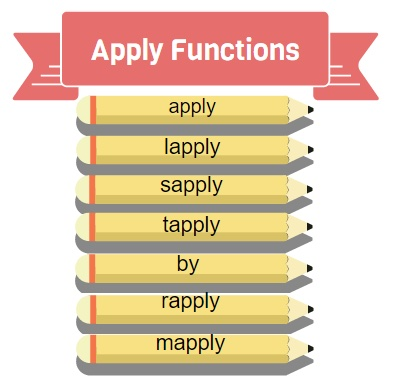

As you discussed previously, one of the issues with for loop can be its memory consumption and its slowness in executing a repetitive task at hand. Often dealing with large data and iterating it, for loop is not advised. R provides many few alternatives to be applied on vectors for looping operations. In this section, we deal with **apply** function and its variants. The functions `apply()`, `lapply()`, `sapply()`, `tapply()`, `rapply()` & `mapply()`. As a general definition, *Apply* is a very efficient tool to perform repetitive calculations. In the following examples we test some of the powers of the *applies*.

```r
apply(vaccines[, 4:12], 1, mean, na.rm = TRUE)
```

```
...
##     [1] 0.000000e+00 0.000000e+00 0.000000e+00 0.000000e+00 0.000000e+00
##     [6] 1.000000e+00 8.345500e+03 0.000000e+00 0.000000e+00 0.000000e+00
##    [11] 0.000000e+00 0.000000e+00 0.000000e+00 0.000000e+00 0.000000e+00
##    [16] 0.000000e+00 0.000000e+00 0.000000e+00 0.000000e+00 1.250000e-01
##    [21] 0.000000e+00 0.000000e+00 0.000000e+00 0.000000e+00 0.000000e+00
##    [26] 0.000000e+00 0.000000e+00 0.000000e+00 0.000000e+00 0.000000e+00
##    [31] 0.000000e+00 0.000000e+00 0.000000e+00 0.000000e+00 6.250000e-01
##    [36] 0.000000e+00 0.000000e+00 0.000000e+00 0.000000e+00 0.000000e+00
##    [41] 0.000000e+00 0.000000e+00 0.000000e+00 0.000000e+00 1.250000e-01
##    [46] 0.000000e+00 0.000000e+00 0.000000e+00 0.000000e+00 1.137500e+01
##    [51] 0.000000e+00 0.000000e+00 0.000000e+00 1.662500e+02 0.000000e+00
##    [56] 0.000000e+00 0.000000e+00 0.000000e+00 6.250000e-01 0.000000e+00
##    [61] 0.000000e+00 0.000000e+00 0.000000e+00 0.000000e+00 0.000000e+00
##    [66] 0.000000e+00 1.313750e+02 2.500000e-01 0.000000e+00 0.000000e+00
##    [71] 0.000000e+00 0.000000e+00 0.000000e+00 0.000000e+00 0.000000e+00
##    [76] 0.000000e+00 0.000000e+00 1.250000e-01 0.000000e+00 0.000000e+00
##    [81] 0.000000e+00 0.000000e+00 0.000000e+00 0.000000e+00 0.000000e+00
##    [86] 0.000000e+00 0.000000e+00 0.000000e+00 0.000000e+00 7.512500e+01
##    [91] 0.000000e+00 0.000000e+00 0.000000e+00 0.000000e+00 0.000000e+00
##    [96] 0.000000e+00 0.000000e+00 7.050000e+01 0.000000e+00 0.000000e+00
##   [101] 0.000000e+00 0.000000e+00 0.000000e+00 0.000000e+00 2.127500e+02
##   [106] 0.000000e+00 0.000000e+00 0.000000e+00 0.000000e+00 0.000000e+00
##   [111] 0.000000e+00 8.750000e-01 0.000000e+00 0.000000e+00 0.000000e+00
##   [116] 0.000000e+00 0.000000e+00 0.000000e+00 0.000000e+00 0.000000e+00
##   [121] 8.750000e-01 0.000000e+00 0.000000e+00 0.000000e+00 2.500000e-01
...
```

```r
apply(vaccines[, 4:12], 2, mean, na.rm = TRUE)  # 1 for row-wise operation, 2 for column-wise
```

[output not shown]

```r
lapply(by(vaccines$Population, vaccines$ReportingCountry, mean),
    log10)
```

```
## $AT
## [1] 6.950965
##
## $BE
## [1] 7.063178
##
## $BG
## [1] 6.839901
##
## $CY
## [1] 5.952294
##
## $CZ
## [1] 7.029454
##
## $DE
## [1] 7.919889
##
## $DK
## [1] 6.766401
##
## $EE
## [1] 6.123872
##
## $EL
## [1] 7.028549
##
## $ES
## [1] 7.67576
##
## $FI
## [1] 6.743009
##
## $FR
## [1] 7.830288
##
## $HR
## [1] 6.606014
##
## $HU
```

[output cut: 34 more lines]

```
##
## $PT
## [1] 7.012763
##
## $RO
## [1] 7.283339
##
## $SE
## [1] 7.016122
##
## $SI
## [1] 6.324052
##
## $SK
## [1] 6.737174
```

```r
sapply(by(vaccines$Population, vaccines$ReportingCountry, mean),
    log10)
```

```
##       AT       BE       BG       CY       CZ       DE       DK       EE
## 6.950965 7.063178 6.839901 5.952294 7.029454 7.919889 6.766401 6.123872
##       EL       ES       FI       FR       HR       HU       IE       IS
## 7.028549 7.675760 6.743009 7.830288 6.606014 6.988154 6.699501 5.566762
##       IT       LI       LT       LU       LV       MT       NL       NO
## 7.772605 4.591677 6.446486 5.802562 6.277217 5.712724 7.242390 6.731687
##       PL       PT       RO       SE       SI       SK
## 7.577979 7.012763 7.283339 7.016122 6.324052 6.737174
```

```r
class(lapply(by(vaccines$Population, vaccines$ReportingCountry,
    mean), log10))  #lapply take a list (or object that can be coerced as one) and gives a list
```

```
## [1] "list"
```

```r
class(sapply(by(vaccines$Population, vaccines$ReportingCountry,
    mean), log10))  #a wrapper of lapply that returns a vector or matrix instead of a list
```

```
## [1] "numeric"
```

```r
sapply(list(vaccines2$Population, vaccines2$FirstDose, vaccines2$SecondDose,
    vaccines2$NumberDosesReceived), median)  # we can do it with several variables
```

```
## [1] 5533793       0       0      NA
```

```r
sapply(vaccines2, class)  #calculations is a broad concept here
```

```
##         YearWeekISO    ReportingCountry         Denominator NumberDosesReceived
##         "character"         "character"           "integer"           "integer"
## NumberDosesExported           FirstDose    FirstDoseRefused          SecondDose
##           "integer"           "integer"           "integer"           "integer"
##     DoseAdditional1     DoseAdditional2     DoseAdditional3         UnknownDose
##           "integer"           "integer"           "integer"           "integer"
##              Region         TargetGroup             Vaccine          Population
##         "character"         "character"         "character"           "integer"
```

```r
# mapply is a matrix (or multivariable) version
mapply(sub, vaccines2[, 4], vaccines2[, 6], vaccines2[, 7])
```

```
##         NumberDosesReceived
##    [1,] NA
##    [2,] NA
##    [3,] NA
##    [4,] NA
##    [5,] NA
##    [6,] NA
##    [7,] NA
##    [8,] NA
##    [9,] NA
##   [10,] NA
##   [11,] NA
##   [12,] NA
##   [13,] NA
##   [14,] NA
```

[output cut: 986 more lines]

```r
mapply(rep, letters[1:4], 4:1)
```

```
## $a
## [1] "a" "a" "a" "a"
##
## $b
## [1] "b" "b" "b"
##
## $c
## [1] "c" "c"
##
## $d
## [1] "d"
```

```r
# tapply breaks a vector into pieces, can be used instead
# of aggregate
tapply(vaccines$NumberDosesReceived, vaccines$ReportingCountry,
    median, na.rm = TRUE)
```

```
##    AT    BE    BG    CY    CZ    DE    DK    EE    EL    ES    FI    FR    HR
##     0     0     0     0     0 53900     0     0     0     0 87750     0 32400
##    HU    IE    IS    IT    LI    LT    LU    LV    MT    NL    NO    PL    PT
##     0     0  1300    62     0     0     0     0    NA     0     0     0     0
##    RO    SE    SI    SK
##     0     0     0     0
```

```r
tapply(coli_genomes$VF, coli_genomes$Source, mean, na.rm = TRUE)
```

```
##     Avian     Human   Porcine
##  7.333333 11.266667  4.500000
```

```r
# vapply is similar to sapply, but has a pre-specified type
# of return value
vapply(vaccines[, 8:11], mean, numeric(1))
```

```
##      SecondDose DoseAdditional1 DoseAdditional2 DoseAdditional3
##     1582.874050     1251.687770      196.243314        4.458589
```

```r
vapply(vaccines[, 8:11], function(x) x^2, numeric(nrow(vaccines)))
```

```
##             SecondDose DoseAdditional1 DoseAdditional2 DoseAdditional3
##      [1,] 0.000000e+00    0.000000e+00               0               0
##      [2,] 0.000000e+00    0.000000e+00               0               0
##      [3,] 0.000000e+00    0.000000e+00               0               0
##      [4,] 0.000000e+00    0.000000e+00               0               0
##      [5,] 0.000000e+00    0.000000e+00               0               0
##      [6,] 0.000000e+00    0.000000e+00               0               0
##      [7,] 0.000000e+00    0.000000e+00               0               0
##      [8,] 0.000000e+00    0.000000e+00               0               0
##      [9,] 0.000000e+00    0.000000e+00               0               0
##     [10,] 0.000000e+00    0.000000e+00               0               0
##     [11,] 0.000000e+00    0.000000e+00               0               0
##     [12,] 0.000000e+00    0.000000e+00               0               0
##     [13,] 0.000000e+00    0.000000e+00               0               0
##     [14,] 0.000000e+00    0.000000e+00               0               0
```

[output cut: 24986 more lines]

```r
# rapply for recursive calculations
rapply(vaccines, mean, class = "integer")
```

```
##         Denominator NumberDosesReceived NumberDosesExported           FirstDose
##                  NA                  NA                  NA        1.749675e+03
##    FirstDoseRefused          SecondDose     DoseAdditional1     DoseAdditional2
##                  NA        1.582874e+03        1.251688e+03        1.962433e+02
##     DoseAdditional3         UnknownDose          Population
##        4.458589e+00        1.395121e+01        1.574692e+07
```

```r
rapply(vaccines, table, class = "factor")
```

[output not shown]

```r
vaccines$ReportingCountry <- as.factor(vaccines$ReportingCountry)
vaccines$Vaccine <- as.factor(vaccines$Vaccine)
vaccines$TargetGroup <- as.factor(vaccines$TargetGroup)
vaccines$Region <- as.factor(vaccines$Region)
rapply(vaccines, table, class = "factor")  #factors need to be defined and now it gives the counts for each group of each factor
```

```
##  ReportingCountry.AT  ReportingCountry.BE  ReportingCountry.BG
##                11520                 4510                 3977
##  ReportingCountry.CY  ReportingCountry.CZ  ReportingCountry.DE
##                 4237                 3967                  594
##  ReportingCountry.DK  ReportingCountry.EE  ReportingCountry.EL
##                 3922                 3741                10752
##  ReportingCountry.ES  ReportingCountry.FI  ReportingCountry.FR
##                 5820               269568                15604
##  ReportingCountry.HR  ReportingCountry.HU  ReportingCountry.IE
##                 7005                 4939                 3001
##  ReportingCountry.IS  ReportingCountry.IT  ReportingCountry.LI
##                 3850                10148                 3030
##  ReportingCountry.LT  ReportingCountry.LU  ReportingCountry.LV
##                 6868                 5244                 5705
##  ReportingCountry.MT  ReportingCountry.NL  ReportingCountry.NO
##                 4028                 5940                 2616
##  ReportingCountry.PL  ReportingCountry.PT  ReportingCountry.RO
##               106080                 7882                 3245
##  ReportingCountry.SE  ReportingCountry.SI  ReportingCountry.SK
##                 6113                 2371                 2964
##            Region.AT            Region.BE            Region.BG
##                11520                 4510                 3977
##            Region.CY            Region.CZ            Region.DE
##                 4237                 3967                  594
##            Region.DK            Region.EE            Region.EL
##                 3922                 3741                10752
##            Region.ES            Region.FI          Region.FI19
##                 5820                11232                11232
##         Region.FI193         Region.FI194         Region.FI195
##                11232                11232                11232
##         Region.FI197          Region.FI1B         Region.FI1B1
##                11232                11232                11232
##          Region.FI1C         Region.FI1C1         Region.FI1C2
##                11232                11232                11232
##         Region.FI1C3         Region.FI1C4         Region.FI1C5
##                11232                11232                11232
##          Region.FI1D         Region.FI1D1         Region.FI1D2
##                11232                11232                11232
##         Region.FI1D3         Region.FI1D5         Region.FI1D7
##                11232                11232                11232
```

[output cut: 71 more lines]

```
##                41303                41013                34528
##      TargetGroup.ALL      TargetGroup.HCW     TargetGroup.LTCF
##                56499                14998                 5702
##           Vaccine.AZ       Vaccine.BECNBG       Vaccine.BHACOV
##                75003                 1847                  183
##          Vaccine.COM      Vaccine.COMBA.1    Vaccine.COMBA.4-5
##                83781                33897                33422
##       Vaccine.COMBIV        Vaccine.JANSS          Vaccine.MOD
##                    6                74417                81117
##      Vaccine.MODBA.1    Vaccine.MODBA.4-5       Vaccine.MODBIV
##                 1744                   49                    6
##         Vaccine.NVXD          Vaccine.SIN          Vaccine.SPU
##                61004                  976                  683
##          Vaccine.UNK          Vaccine.VLA
##                49997                31109
```

```r
rapply(vaccines, median, how = "list", class = "integer", na.rm = TRUE)  #returns a list
```

```
## $YearWeekISO
## NULL
##
## $ReportingCountry
## NULL
##
## $Denominator
## [1] 258230
##
## $NumberDosesReceived
## [1] 0
##
## $NumberDosesExported
## [1] 0
##
## $FirstDose
## [1] 0
##
## $FirstDoseRefused
## [1] 0
##
## $SecondDose
## [1] 0
##
## $DoseAdditional1
## [1] 0
##
## $DoseAdditional2
## [1] 0
##
## $DoseAdditional3
## [1] 0
##
## $UnknownDose
## [1] 0
##
## $Region
## NULL
##
## $TargetGroup
## NULL
##
## $Vaccine
## NULL
##
## $Population
## [1] 5533793
```

```r
rapply(vaccines, median, how = "unlist", class = "integer", na.rm = TRUE)  #gives a vector
```

```
##         Denominator NumberDosesReceived NumberDosesExported           FirstDose
##              258230                   0                   0                   0
##    FirstDoseRefused          SecondDose     DoseAdditional1     DoseAdditional2
##                   0                   0                   0                   0
##     DoseAdditional3         UnknownDose          Population
##                   0                   0             5533793
```

```r
# what do you mean by RECURSIVELY?
x <- list("a", list(24, 443), 434, list(54, list(6443, 7234)))  #this is a complex list with sublists

str(x)
```

```
## List of 4
##  $ : chr "a"
##  $ :List of 2
##   ..$ : num 24
##   ..$ : num 443
##  $ : num 434
##  $ :List of 2
##   ..$ : num 54
##   ..$ :List of 2
##   .. ..$ : num 6443
##   .. ..$ : num 7234
```

```r
rapply(x, log2, class = c("numeric"))
```

```
## [1]  4.584963  8.791163  8.761551  5.754888 12.653517 12.820578
```

```r
(r <- rapply(x, log2, class = c("numeric"), how = "unlist"))
```

```
## [1]  4.584963  8.791163  8.761551  5.754888 12.653517 12.820578
```

```r
str(r)
```

```
##  num [1:6] 4.58 8.79 8.76 5.75 12.65 ...
```

Note that `tapply()` and `by()` are very similar. Indeed, `by()` is a wrapper of `tapply()`. On the other hand, `vapply()` is similar to `sapply`, but has a pre-specified type of return value, so it can be safer (or faster) to use sometimes. Finally, `rapply()` is not very often used, but it can be the best option for complex datasets, like those including nested lists or complex lists with several dataframes and/or vectors.

The applications of *apply* functions are very wide. You can use them to parse data with many different input and output structures, even for plots (see Lesson 11).

# References

- Manipulación de datos en R: https://r-coder.com/manipulacion-datos-r/ [ES] & https://r-coder.com/r-data-manipulation/ [EN]
- *R in action.* Robert I. Kabacoff. March 2022 ISBN 9781617296055
- Working with tables in R: https://bookdown.org/kdonovan125/ibis_data_analysis_r4/working-with-tables-in-r.html
- About flat tables in R: https://cran.r-project.org/web/packages/memisc/vignettes/ftable-matrix.html
- *data.table* cheatsheet: https://raw.githubusercontent.com/rstudio/cheatsheets/main/datatable.pdf
- Data aggregation: https://r-coder.com/aggregate-r/
- About *Applies*: https://www.r-bloggers.com/2016/03/apply-lapply-rapply-sapply-functions-in-r-2/ & https://gist.github.com/lyndametref/4d137fcba1ec4d9af80ad53245b358ff

# Exercises

#### 1. Using the *merge3* dataset, create a data matrix table containing the strain name and the columns Plasmids, CRISPR, VR and AMR are transformed as a single variable.

#### 2. Two students enrolled in different University courses: Rafa in A,B,D, E and G and Roger in B, C, D and F. Rafa got the following marks 8, 9 ,9.5, 8.75 and 9 and Roger obtained 10, 9.7, 9 and 10. Write a R program to create merged dataframes with all the marks (outer join), all the Rafa’s marks (left outer), all the Roger’s marks (right outer), and the marks in the common courses (inner join).

#### 3. We are using the Covid19 test data for exercises 3-6. You can download the updated *csv* file from https://opendata.ecdc.europa.eu/covid19/testing/csv/data.csv (see also https://www.ecdc.europa.eu/en/publications-data/covid-19-testing). Read the data and write the table in your computer as *covid_tests.csv*.

#### 4. Generate two contingency tables showing the number of tests done (1) by country per week and (2) by country per month.

Hint. For the second table, use the function *ISOweek2date()* from the package “ISOweek” to transform the ISO date_week to standard date format.

#### 3. Remove all the character columns to create a subset dataframe named *minitests*. You can use `subset()` and `sapply()` here.

#### 4. Use apply() to obtain the min, max, median and mean of each column.

#### 5. Use `tapply()` to obtain the mean, median and min of new_cases per country and construct a dataframe with the result.

Hint. Consider how to handle NA’s.

#### 6. Create a function that calculates log10() of the mean, apply it to new_cases per country and append it to the dataframe from the previous exercise. Then, write the results in a csv file.

# Short exercises

The topics in this lesson can be dense and bewildering the first time. I selected some sheets of exercises from great websites that can give you an extra practice.

- https://www.r-exercises.com/2016/04/14/merging-dataframes-exercises/
- https://www.r-bloggers.com/2016/05/cross-tabulation-with-xtabs-exercises/
- https://www.r-exercises.com/2016/09/08/efficient-processing-with-apply-exercises/
- https://www.r-exercises.com/2016/06/16/summary-statistics-with-aggregate/

# [Course home](https://mredrejo.github.io/HPBBM2022/)

### Lesson 9: Data input and output in R

### Lesson 10: Write your own functions

### Lesson 11: Plots

### Lesson 13: Advanced plots with ggplot

### Lesson 14: Applications for Molecular Biology

### Extra Lesson: Introduction to R projects, R Markdown and Quarto.